# Further Exploration and Model

4/30 Presentation

# Further Exploration

We noticed from EDA that the `count` variable was very right-skewed, and had a large range including regions with very sparse data. To examine this further, and to potentially determine if there was a range of the `count` data that could be used for prediction, we decided to look at the range from a count of 10 to the mean (51.9) plus one standard deviation (1616.5), which is 1668.4 birds.

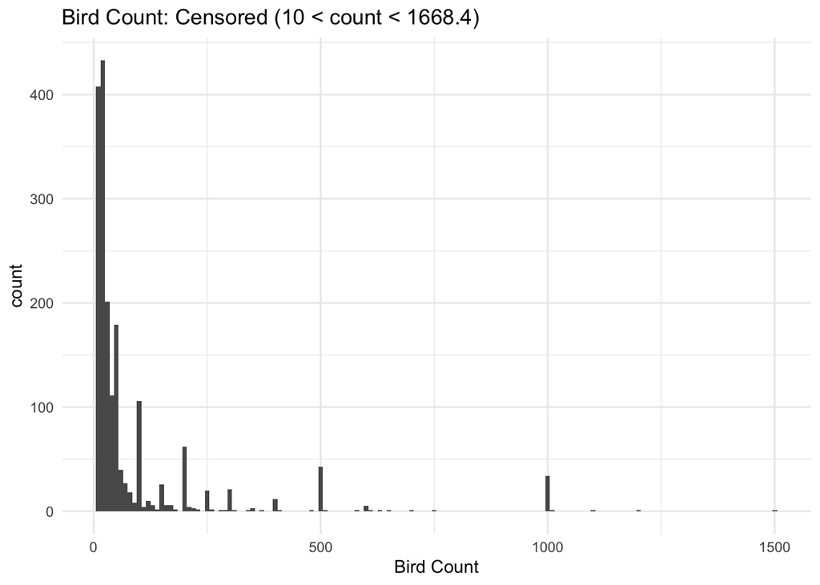

```r
library(tidyverse)
library(caret) # will be needed for CV later
library(pROC) # will be needed for logistic regression models
library(rpart) #for decision tree
library(rpart.plot) #to plot decision tree
library(pheatmap) #for confusion matrix

#read in the cleaned data
data <- read_csv("birds_clean.csv")

# Plot the censored data
data_smallcount <- data %>%
  filter(count > 10, count < 1668.4)

ggplot(data_smallcount, aes(x = count)) +
  geom_histogram(binwidth = 10) +
  labs(
    title = "Bird Count: Censored (10 < count < 1668.4)",
    x = "Bird Count"
  ) +
  theme_minimal()
```

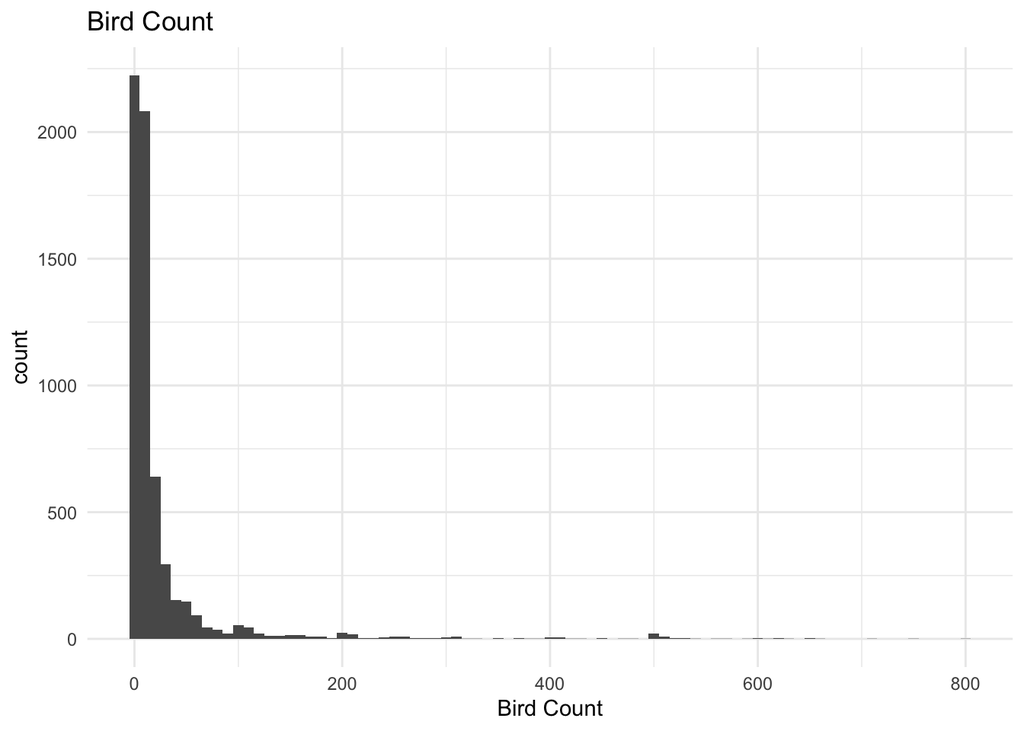

```r
##3 aggregate records so total_birds is the total number of birds recorded in a given session, since currently "count" is total numbers of a specific species of birds recorded in a given session
session_data <- data %>%
  group_by(record_id) %>%
  summarize(
    # calculate total birds seen during the entire observation session
    total_birds = sum(count, na.rm = TRUE),

    # keep the spatial and environmental variables for the session
    latitude = first(latitude),
    longitude = first(longitude),
    sea_state_description = first(sea_state_description),
    wind_description = first(wind_description),
    precipitation = first(precipitation),
    season = first(season),
    cloud_cover = first(cloud_cover),
    .groups = 'drop'
  ) %>%
  mutate( # also make birds interval
    bird_interval_four = cut(total_birds,  # by four
                        breaks = c(-Inf, 10, 50, 100, Inf),
                        labels = c("0-10", "11-50", "51-100", "100+"),
                        ordered_result = TRUE),
    bird_interval_two = cut(total_birds,  # by two (binary)
                        breaks = c(-Inf, 50, Inf),
                        labels = c("0-50", "51+"),
                        ordered_result = TRUE)
  )

#plot  aggregates
ggplot(session_data %>% filter(total_birds < 1000), aes(x = as.numeric(total_birds))) +
  geom_histogram(binwidth = 10) +
  labs(
    title = "Bird Count",
    x = "Bird Count"
  ) +
  theme_minimal()
```

Looking at this much smaller region of the `count` data compared to the whole dataset, this is much more interpretable, but we can still see the issue of a heavy right-skew and regions with sparse data. Since there were so many observations with no birds, we decided to make a new variable that transformed the bird count variable into a binary variable. Then, we could make a Logistic Regression model to predict the appearance of birds. We decided to transform the total number of birds variable in two ways: the first being `count` is greater than 1 or `count` is less than or equal to 1, and the second being `total_birds` is 0-50, or 51+. The first model uses the `df_logistic` dataset, and the second model uses the aggregated `session_data` set.

```
Generalized Linear Model

17537 samples
   10 predictor
    2 classes: 'X0', 'X1'

No pre-processing
Resampling: Cross-Validated (10 fold)
Summary of sample sizes: 15783, 15783, 15783, 15783, 15783, 15783, ...
Resampling results:

  ROC        Sens       Spec
  0.6463956  0.5861116  0.6169494
```

```
Confusion Matrix and Statistics

          Reference
Prediction   X0   X1
        X0 1620 1165
        X1 1187 1873

               Accuracy : 0.5976
                 95% CI : (0.5849, 0.6102)
    No Information Rate : 0.5198
    P-Value [Acc > NIR] : <2e-16

                  Kappa : 0.1937

 Mcnemar's Test P-Value : 0.665

            Sensitivity : 0.5771
            Specificity : 0.6165
         Pos Pred Value : 0.5817
         Neg Pred Value : 0.6121
             Prevalence : 0.4802
         Detection Rate : 0.2772
   Detection Prevalence : 0.4765
      Balanced Accuracy : 0.5968

       'Positive' Class : X0
```

```
Area under the curve: 0.6384
```

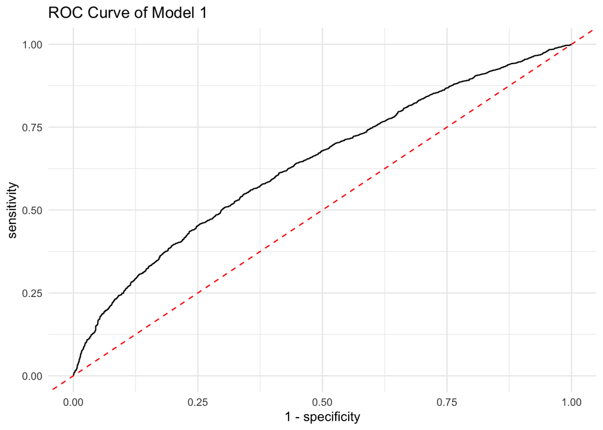

```
Generalized Linear Model

4664 samples
   7 predictor
   2 classes: 'X0', 'X1'

No pre-processing
Resampling: Cross-Validated (10 fold)
Summary of sample sizes: 4198, 4198, 4197, 4197, 4197, 4198, ...
Resampling results:

  ROC        Sens  Spec
  0.6168806  1     0
```

```
Confusion Matrix and Statistics

          Reference
Prediction   X0   X1
        X0 1393  161
        X1    0    0

               Accuracy : 0.8964
                 95% CI : (0.8802, 0.9111)
    No Information Rate : 0.8964
    P-Value [Acc > NIR] : 0.521

                  Kappa : 0

 Mcnemar's Test P-Value : <2e-16

            Sensitivity : 1.0000
            Specificity : 0.0000
         Pos Pred Value : 0.8964
         Neg Pred Value :    NaN
             Prevalence : 0.8964
         Detection Rate : 0.8964
   Detection Prevalence : 1.0000
      Balanced Accuracy : 0.5000

       'Positive' Class : X0
```

```
Area under the curve: 0.5815
```

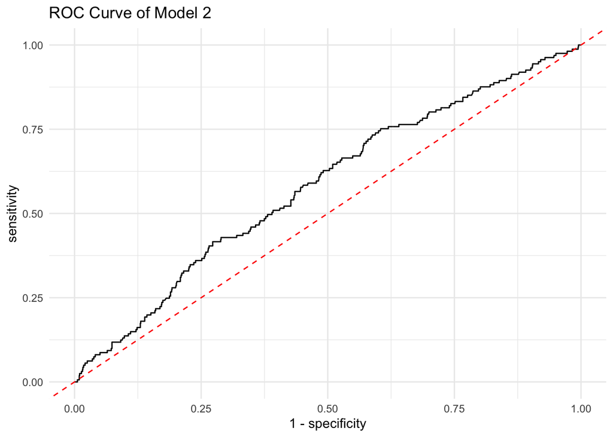

Based on these two logistic regression models, it appears that the model that separates the `birds` variable into `count` is greater than 1 and `count` is less than or equal to 1 (Model 1) performs slightly better (AUC_1 = 0.6384 vs AUC_2 = 0.5815). This indicates that Model 1 has a slightly better discrimination ability than Model 2, though neither is excellent.

To further examine our data, we decided to run a Decision Tree to classify the total birds into smaller intervals.

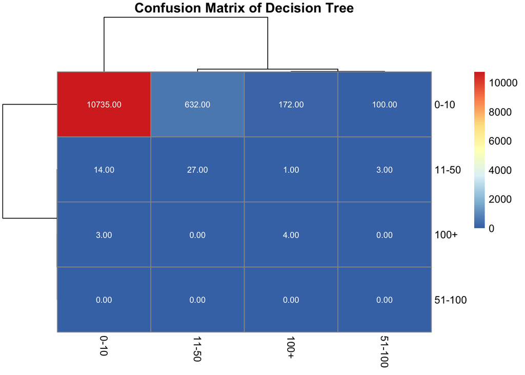